# Exploring the BRFSS data

## Setup

### Load packages

```r
library(tidyverse)
library(ggplot2)
library(maps)
```

### Load data

Make sure your data and R Markdown files are in the same directory. When loaded your data file will be called `brfss2013`. Delete this note when before you submit your work.

```r
load("brfss2013.RData")
```

## Part 1: Data

## Part 2: Research questions

**Research quesion 1: What are the US states with highest proportion of smoking who smoke every day relative to all those respondents who smoke?**

**Research quesion 2: What percentage of non-retired, employed college graduates and non-retired non-college graduates make more than $50,000 per year?**

**Research quesion 3: What are the most popular types of exercise for individuals who have no bad mental health days in the past 30 days and those who have more than 15 bad mental health days in the past 30 days?**

## Part 3: Exploratory data analysis

NOTE: Insert code chunks as needed by clicking on the “Insert a new code chunk” button (green button with orange arrow) above. Make sure that your code is visible in the project you submit. Delete this note when before you submit your work.

**Research quesion 1:**

1st, let’s look at the number of records in each state.

```r
# get count observations from each states
brfss2013 %>%
  group_by(X_state) %>%
  summarise(count = n())
```

```
## # A tibble: 55 x 2
##                 X_state count
##                  <fctr> <int>
##  1                    0     1
##  2              Alabama  6505
##  3               Alaska  4578
##  4              Arizona  4253
##  5             Arkansas  5268
##  6           California 11518
##  7             Colorado 13649
##  8          Connecticut  7710
##  9             Delaware  5206
## 10 District of Columbia  4931
## # ... with 45 more rows
```

So there’s a state “0”? That can’t be right, but it might just be some kind of header. I’ll come back to that later.

Now to look at the frequency table of the **smokday2** variable, which is a description of the frequency of days a respondent is now smoking, ranging from “not at all”" to “every day”.

```r
summary(brfss2013$smokday2)
```

```
##  Every day  Some days Not at all       NA's
##      55163      21494     138135     276983
```

It looks like the majority of people do not smoke, which is good. But there’s a lot of NA values in this dataset for this variable. Let’s get only those who answered the smoking question into a subset titled **smoking**.

```r
# get only those who answered frequency of smoking question
smoking <- brfss2013 %>%
  filter(!is.na(smokday2))
```

Now I need to get the proportion of those who smoke every day by taking the proportion of the “Every day” response and filtering down to just those respondents. Then, I can look at those states with the highest proportion of those who smoke every day.

```r
# get proportion of each level of smoking by state
smoking %>%
  group_by(X_state, smokday2) %>%
  summarise(count = n()) %>%
  mutate(prop = count / sum(count)) %>%
  filter(smokday2 == "Every day") %>%
  arrange(desc(prop))
```

```
## # A tibble: 53 x 4
## # Groups:   X_state [53]
##          X_state  smokday2 count      prop
##           <fctr>    <fctr> <int>     <dbl>
##  1          Guam Every day   312 0.4105263
##  2 West Virginia Every day  1148 0.3890207
##  3      Kentucky Every day  1795 0.3437380
##  4          Ohio Every day  1818 0.3301253
##  5     Tennessee Every day   869 0.3281722
##  6      Missouri Every day  1038 0.3107784
##  7   Mississippi Every day   940 0.3031280
##  8        Alaska Every day   670 0.2983081
##  9      Arkansas Every day   738 0.2972211
## 10       Indiana Every day  1403 0.2948718
## # ... with 43 more rows
```

It seems Guam has the highest proportion of people who say the smoke every day. According to the codebook for this dataset, Guam and Puerto Rico are includedbecause they are US territories. Now I want to check if there are any other options for X_state other than US states and territories.

```r
levels(smoking$X_state)
```

```
##  [1] "0"                    "Alabama"              "Alaska"
##  [4] "Arizona"              "Arkansas"             "California"
##  [7] "Colorado"             "Connecticut"          "Delaware"
## [10] "District of Columbia" "Florida"              "Georgia"
## [13] "Hawaii"               "Idaho"                "Illinois"
## [16] "Indiana"              "Iowa"                 "Kansas"
## [19] "Kentucky"             "Louisiana"            "Maine"
## [22] "Maryland"             "Massachusetts"        "Michigan"
## [25] "Minnesota"            "Mississippi"          "Missouri"
## [28] "Montana"              "Nebraska"             "Nevada"
## [31] "New Hampshire"        "New Jersey"           "New Mexico"
## [34] "New York"             "North Carolina"       "North Dakota"
## [37] "Ohio"                 "Oklahoma"             "Oregon"
## [40] "Pennsylvania"         "Rhode Island"         "South Carolina"
## [43] "South Dakota"         "Tennessee"            "Texas"
## [46] "Utah"                 "Vermont"              "Virginia"
## [49] "Washington"           "West Virginia"        "Wisconsin"
## [52] "Wyoming"              "Guam"                 "Puerto Rico"
## [55] "80"
```

Okay, so it looks like I need to remove Guam and Puerto Rico, the US territories. I also need to remove the “0” and the “80”. I’ll keep the District of Columbia even though it’s not really a *state*.

I can create a function to do the opposite of **%in%** to remove those records with the above values for X_state, then get the proportions of those who smoke every day relative to every respondent to the question and then arranging the results by descending proportion of those who smoke every day.

```r
# function to be opposite of %IN%
`%not in%` <- function (x, table) is.na(match(x, table, nomatch=NA_integer_))

# keep only us official states
(top_every_day_smoker_states <- smoking %>%
    filter(X_state %not in% c("0", "80", "Guam", "Puerto Rico")) %>%
    group_by(X_state, smokday2) %>%
    summarise(count = n()) %>%
    mutate(prop = count / sum(count)) %>%
    filter(smokday2 == "Every day") %>%
    arrange(desc(prop)))
```

```
## # A tibble: 51 x 4
## # Groups:   X_state [51]
##          X_state  smokday2 count      prop
##           <fctr>    <fctr> <int>     <dbl>
##  1 West Virginia Every day  1148 0.3890207
##  2      Kentucky Every day  1795 0.3437380
##  3          Ohio Every day  1818 0.3301253
##  4     Tennessee Every day   869 0.3281722
##  5      Missouri Every day  1038 0.3107784
##  6   Mississippi Every day   940 0.3031280
##  7        Alaska Every day   670 0.2983081
##  8      Arkansas Every day   738 0.2972211
##  9       Indiana Every day  1403 0.2948718
## 10      Oklahoma Every day  1140 0.2928333
## # ... with 41 more rows
```

I now want to create a heatmap to see which states have the highest proportion of those who smoke every day.

[figure not shown]

```r
top_every_day_smoker_states$region <- tolower(top_every_day_smoker_states$X_state)

states <- map_data("state")
map.df <- merge(states,top_every_day_smoker_states, by = "region", all.x = T)
map.df <- map.df[order(map.df$order),]
ggplot(map.df, aes(x = long, y = lat, group = group)) +
  geom_polygon(aes(fill=prop)) +
  geom_path() +
  scale_fill_gradientn(colours = rev(heat.colors(10)), na.value="grey90") +
  coord_map() +
  theme(rect = element_blank(), axis.text.x = element_blank(),
        axis.text.y = element_blank(), axis.ticks = element_blank()) + # remove grid background and ticks and tick labels
  ggtitle("Heatmap of the Proportion of Everyday Smokers in the United States") +
  labs(caption="* Data reflects statistics for those who have responses for the variable smokday2: 54516 respondents",
       x = element_blank(), y = element_blank())
```

Now I want to visualize the proportions of the top 10 states with the highest proportion of everyday smokers.

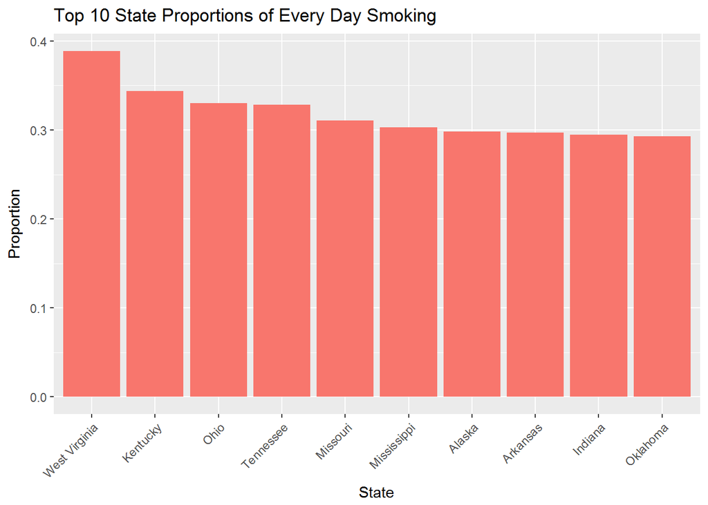

```r
#top 15 states
top_every_day_smoker_states %>%
  head(10) %>%
  ggplot() +
  geom_bar(aes(reorder(X_state, -prop), prop, fill = "Red"), stat = "identity") +
  theme(axis.text.x = element_text(angle = 45, hjust = 1)) +
  xlab('State') +
  ylab('Proportion') +
  ggtitle('Top 10 State Proportions of Every Day Smoking') +
  guides(fill=FALSE)
```

Let’s also look at the these proportions along those who don’t smoke at all and those who smoke some days for these same states.

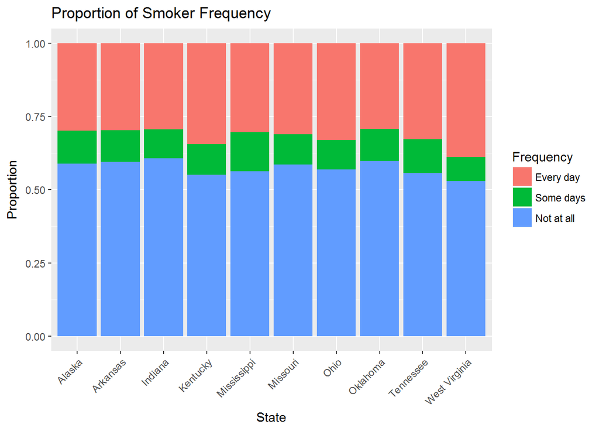

```r
#get those top 15 states
top_every_day_states <- top_every_day_smoker_states %>%
  head(10) %>%
  select(X_state) %>%
  as.data.frame() #%>%

# array of character elements of the state names
top_every_day_states <- top_every_day_states[,1]

smoking %>%
  group_by(X_state, smokday2) %>%
  summarise(count = n()) %>%
  mutate(prop = count / sum(count)) %>%
  arrange(desc(prop)) %>%
  filter(X_state %in% top_every_day_states) %>% # get only top 10 states
  ggplot() +
  geom_bar(aes(X_state, prop, fill = smokday2), stat = "identity") + # stacked bar chart
  theme(axis.text.x = element_text(angle = 45, hjust = 1)) +
  xlab("State") +
  ylab("Proportion") +
  ggtitle("Proportion of Smoker Frequency") +
  guides(fill=guide_legend(title="Frequency"))
```

**Research quesion 2:**

Now I want to see if there is a discrepency in the proportions of the salaries of both college graduates and non-college graduates compared to the median household salary in the US. First, I need to filter out the US territories like above and also filter down to just college gradutes to start with.

```r
united.states <- brfss2013 %>%
  filter(X_state %not in% c("0", "80", "Guam", "Puerto Rico"))

united.states %>%
  filter(educa == "College 4 years or more (College graduate)") %>%
  count
```

```
## # A tibble: 1 x 1
##        n
##    <int>
## 1 167798
```

We end up with about 168,000 observations. I also want to filter down to those graduates that are actually working, which would only include those respondents that are employed for wages or are self-employed.

```r
us_college_grads_not_retired <- brfss2013 %>%
  filter(educa == "College 4 years or more (College graduate)",
         employ1 %in% c("Employed for wages","Self-employed"))
```

I also know the income level has been put into buckets that have levels made up of character strings, such as “Less than $20,000”. I want to recode that into numerics so I can rank them and then look at a histogram of the distribution of the incomes of non-retired, working college graduates in the United States.

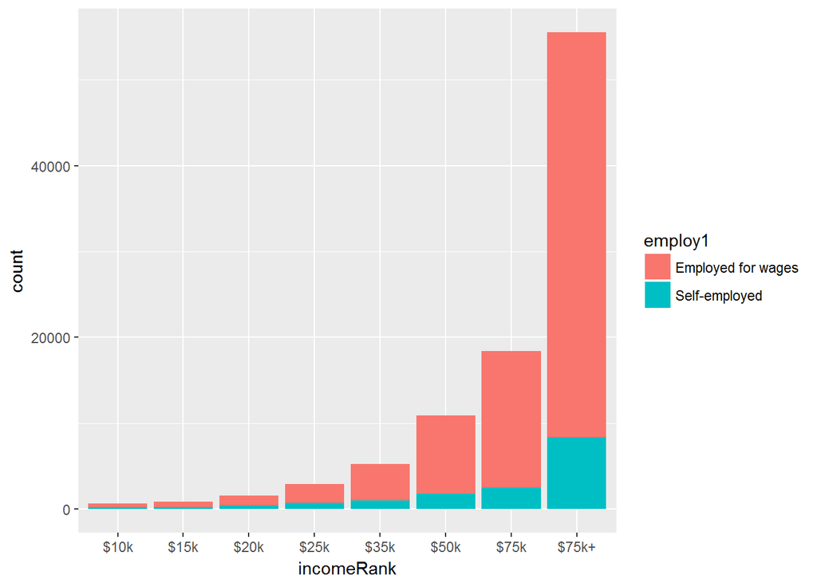

```r
# rename factors to numerics
us_college_grads_not_retired$incomeRank <- recode(us_college_grads_not_retired$income2, "Less than $10,000" = 1, "Less than $15,000" = 2,
                                                                                "Less than $20,000" = 3, "Less than $25,000" = 4,
                                                                                "Less than $35,000" = 5, "Less than $50,000" = 6,
                                                                              "Less than $75,000" = 7,"$75,000 or more" = 8)

us_college_grads_not_retired$incomeRank <- factor(us_college_grads_not_retired$incomeRank, labels = c("$10k","$15k","$20k","$25k",
                                                                                                      "$35k","$50k","$75k","$75k+"))
us_college_grads_not_retired %>%
  filter(!is.na(incomeRank)) %>%
  ggplot() +
   geom_histogram(aes(incomeRank, fill = employ1), binwidth = 1, stat = "count")
```

The overwhelming majority of those college graduates currently working is over $75,000 per year in this dataset, with most of them being employed for wages, compared to self-employed respondents. The median household income in $56,516 in 2016. So, I want to see what percentage of employed college graduates are (most likely) making more than this. I’ll use income buckets of greater than $50,000 per year as my minimum. The rank of this bucket was 6, so I need all records with income ranks greater than 6.

```r
# percent of people making more than 50k
us_college_grads_not_retired %>%
  summarize(prop = mean(as.numeric(incomeRank) > 6, na.rm = T))
```

```
##        prop
## 1 0.7699314
```

```r
us_college_grads_not_retired %>%
  group_by(employ1) %>%
  summarize(prop = mean(as.numeric(incomeRank) > 6, na.rm = T))
```

```
## # A tibble: 2 x 2
##              employ1      prop
##               <fctr>     <dbl>
## 1 Employed for wages 0.7800770
## 2      Self-employed 0.7158318
```

So, it appears that about 77% of currently-employed college graduates make more than $50,000 per year, and are most likely making more than the median household income of the United States.

And, after splitting out to self-employed and employed for wages, an ever higher of employed for wages employees are making above this bucket, while a smaller percentage of self-employed respondents are making above this bucket.

Now, let’s look at the same question, but for those who did not graduate college (and actually answered the question).

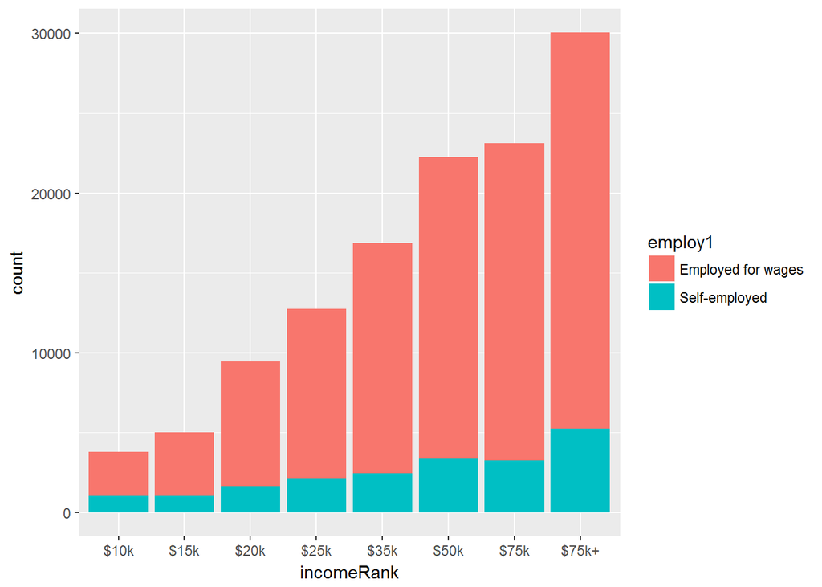

```r
non_grads_not_retired <- brfss2013 %>%
  filter(educa %not in% c("College 4 years or more (College graduate)","Refused"),
         employ1 %in% c("Employed for wages","Self-employed"))

# rename factors to numerics
non_grads_not_retired$incomeRank <- recode(non_grads_not_retired$income2, "Less than $10,000" = 1, "Less than $15,000" = 2,
                                               "Less than $20,000" = 3, "Less than $25,000" = 4,
                                               "Less than $35,000" = 5, "Less than $50,000" = 6,
                                               "Less than $75,000" = 7,"$75,000 or more" = 8)


non_grads_not_retired$incomeRank <- factor(non_grads_not_retired$incomeRank, labels = c("$10k","$15k","$20k","$25k","$35k","$50k",
                                                                                        "$75k","$75k+"))

non_grads_not_retired %>%
  filter(!is.na(incomeRank)) %>%
  ggplot() +
   geom_histogram(aes(incomeRank, fill = employ1), binwidth = 1, stat = "count")
```

But, we can note the disparity is not as large compared to those who did graduate college. The skew is not as severe.

Now to check the percentage of employed non-college graduates that are (most likely) making more than the median US household income.

```r
# percent of people making more than 50k
non_grads_not_retired %>%
  summarize(prop = mean(as.numeric(incomeRank) > 6, na.rm = T))
```

```
##        prop
## 1 0.4310216
```

```r
non_grads_not_retired %>%
  group_by(employ1) %>%
  summarize(prop = mean(as.numeric(incomeRank) > 6, na.rm = T))
```

```
## # A tibble: 2 x 2
##              employ1      prop
##               <fctr>     <dbl>
## 1 Employed for wages 0.4330141
## 2      Self-employed 0.4208255
```

We see that only 43% of currently-employed non-college graduates make more than $50,000 per year, and are most likely making more than the median household income of the United States.

**Research quesion 3:**

For my 3rd research question, I wanted to see what were the most popular types of exercise for individuals who have no bad mental health days in the past 30 days and those who have more than 15 bad mental health days in the past 30 days.

This might possibly lead to insights into how physical activity could affect mental health.

```r
table(brfss2013$menthlth)
```

```
##
##      0      1      2      3      4      5      6      7      8      9
## 334461  15206  23520  13593   6660  16654   1861   6353   1244    198
##     10     11     12     13     14     15     16     17     18     19
##  11917     74    812     97   2516  10910    161    105    181     45
##     20     21     22     23     24     25     26     27     28     29
##   6633    497    113     61     87   2318     89    164    680    415
##     30    247   5000
##  25521      1      1
```

Looks ilke there’s some value above 30, which is an error, since the question asked for the number of bad mental health days in the past 30 days, so there should be no value greater than 30.

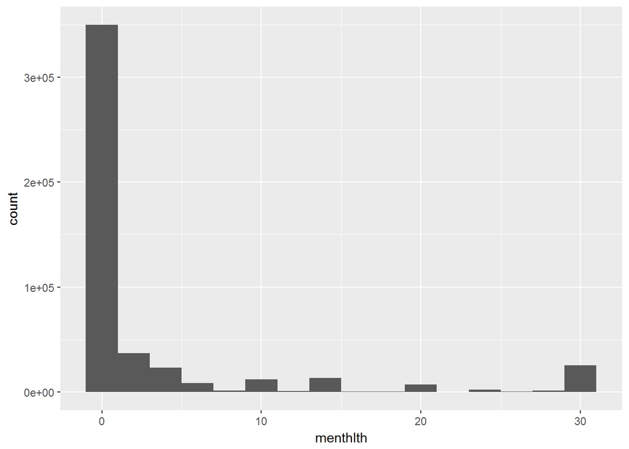

```r
brfss2013 %>%
  filter(menthlth <= 30) %>%
  ggplot() +
    geom_histogram(aes(menthlth), binwidth = 2)
```

So, there’s an incredibly large right skew here, so most people say they have had a low amount of bad mental health days in the past 30 days (at the time of questioning).

Let’s get all those records of individuals with no bad mental health days and those of individuals with more than bad mental health days for over half of the specified time frame.

```r
good_mental_hlth <- brfss2013 %>%
  filter(menthlth == 0 & !is.na(menthlth))

bad_mental_hlth <- brfss2013 %>%
  filter(menthlth > 15 & menthlth <= 30)
```

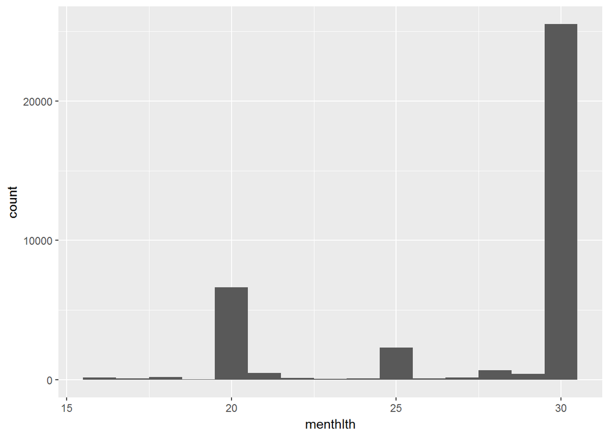

```r
bad_mental_hlth %>%
  ggplot() +
    geom_histogram(aes(menthlth), binwidth = 1)
```

```r
prop.table(table(good_mental_hlth$exerany2)) #many healthy exercises
```

```
##
##      Yes       No
## 0.741974 0.258026
```

```r
prop.table(table(bad_mental_hlth$exerany2)) # more did exercise, not as much
```

```
##
##       Yes        No
## 0.5687793 0.4312207
```

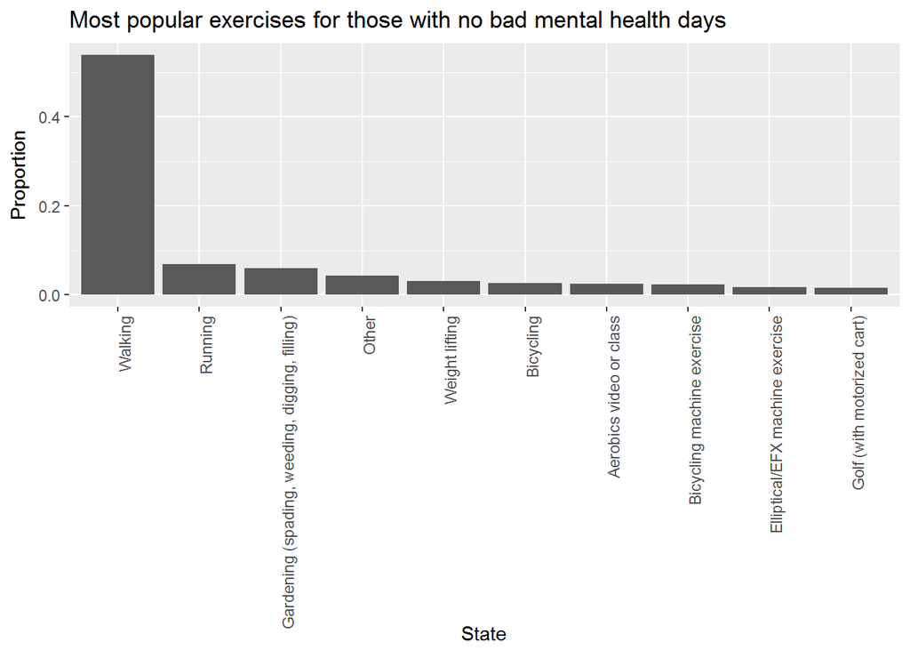

```r
good_mental_hlth %>%
  filter(exerany2 == "Yes") %>%
  group_by(exract11) %>%
  summarize(count = n()) %>%
  mutate(prop = count / sum(count)) %>%
  arrange(desc(prop)) %>%
  head(10) %>%
  ggplot() +
  geom_bar(aes(reorder(exract11, -prop), prop), stat = "identity") +
  theme(axis.text.x = element_text(angle = 90, hjust = 1)) +
  xlab('State') +
  ylab('Proportion') +
  ggtitle('Most popular exercises for those with no bad mental health days')
```

Well, these labels sure make for an ugly chart, but we can see that about half of the exercise activites performed by those with no mental health days was walking, with most others making up less than 10% of activities.

Now let’s check on those with “poor” mental health.

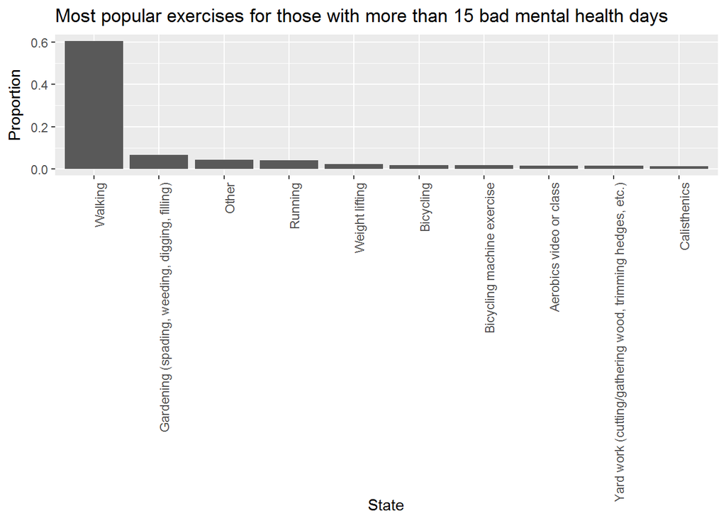

```r
bad_mental_hlth %>%
  filter(exerany2 == "Yes") %>%
  group_by(exract11) %>%
  summarize(count = n()) %>%
  mutate(prop = count / sum(count)) %>%
  arrange(desc(prop)) %>%
  head(10) %>%
  ggplot() +
  geom_bar(aes(reorder(exract11, -prop), prop), stat = "identity") +
  theme(axis.text.x = element_text(angle = 90, hjust = 1)) +
  xlab('State') +
  ylab('Proportion') +
  ggtitle('Most popular exercises for those with more than 15 bad mental health days')
```